# Loan Data from Prosper

## Preliminary Wrangling

This data set contains 113,937 loans with 81 variables on each loan, including loan amount, borrower rate (or interest rate), current loan status, borrower income, and many others.

```python
# import all packages and set plots to be embedded inline
import numpy as np
import pandas as pd
import matplotlib.pyplot as plt
import seaborn as sb

%matplotlib inline
```

> Load in your dataset and describe its properties through the questions below. Try and motivate your exploration goals through this section.

```python
# loading the data into panads
loan_data = pd.read_csv('prosperLoanData.csv')
pd.set_option('display.max_columns', 500)
loan_data.head()
```

|  | ListingKey | ListingNumber | ListingCreationDate | CreditGrade | Term | LoanStatus | ClosedDate | BorrowerAPR | BorrowerRate | LenderYield | EstimatedEffectiveYield | EstimatedLoss | EstimatedReturn | ProsperRating (numeric) | ProsperRating (Alpha) | ProsperScore | ListingCategory (numeric) | BorrowerState | Occupation | EmploymentStatus | EmploymentStatusDuration | IsBorrowerHomeowner | CurrentlyInGroup | GroupKey | DateCreditPulled | CreditScoreRangeLower | CreditScoreRangeUpper | FirstRecordedCreditLine | CurrentCreditLines | … |
| --- | --- | --- | --- | --- | --- | --- | --- | --- | --- | --- | --- | --- | --- | --- | --- | --- | --- | --- | --- | --- | --- | --- | --- | --- | --- | --- | --- | --- | --- | --- |
| 0 | 1021339766868145413AB3B | 193129 | 2007-08-26 19:09:29.263000000 | C | 36 | Completed | 2009-08-14 00:00:00 | 0.16516 | 0.1580 | 0.1380 | NaN | NaN | NaN | NaN | NaN | NaN | 0 | CO | Other | Self-employed | 2.0 | True | True | NaN | 2007-08-26 18:41:46.780000000 | 640.0 | 659.0 | 2001-10-11 00:00:00 | 5.0 | … |
| 1 | 10273602499503308B223C1 | 1209647 | 2014-02-27 08:28:07.900000000 | NaN | 36 | Current | NaN | 0.12016 | 0.0920 | 0.0820 | 0.07960 | 0.0249 | 0.05470 | 6.0 | A | 7.0 | 2 | CO | Professional | Employed | 44.0 | False | False | NaN | 2014-02-27 08:28:14 | 680.0 | 699.0 | 1996-03-18 00:00:00 | 14.0 | … |
| 2 | 0EE9337825851032864889A | 81716 | 2007-01-05 15:00:47.090000000 | HR | 36 | Completed | 2009-12-17 00:00:00 | 0.28269 | 0.2750 | 0.2400 | NaN | NaN | NaN | NaN | NaN | NaN | 0 | GA | Other | Not available | NaN | False | True | 783C3371218786870A73D20 | 2007-01-02 14:09:10.060000000 | 480.0 | 499.0 | 2002-07-27 00:00:00 | NaN | … |
| 3 | 0EF5356002482715299901A | 658116 | 2012-10-22 11:02:35.010000000 | NaN | 36 | Current | NaN | 0.12528 | 0.0974 | 0.0874 | 0.08490 | 0.0249 | 0.06000 | 6.0 | A | 9.0 | 16 | GA | Skilled Labor | Employed | 113.0 | True | False | NaN | 2012-10-22 11:02:32 | 800.0 | 819.0 | 1983-02-28 00:00:00 | 5.0 | … |
| 4 | 0F023589499656230C5E3E2 | 909464 | 2013-09-14 18:38:39.097000000 | NaN | 36 | Current | NaN | 0.24614 | 0.2085 | 0.1985 | 0.18316 | 0.0925 | 0.09066 | 3.0 | D | 4.0 | 2 | MN | Executive | Employed | 44.0 | True | False | NaN | 2013-09-14 18:38:44 | 680.0 | 699.0 | 2004-02-20 00:00:00 | 19.0 | … |

```python
loan_data.shape
```

```
(113937, 81)
```

```python
loan_data['LoanKey'].duplicated().value_counts()
```

```
False    113066
True        871
Name: LoanKey, dtype: int64
```

```python
loan_data['ListingKey'].duplicated().value_counts()
```

```
False    113066
True        871
Name: ListingKey, dtype: int64
```

```python
loan_data['CreditGrade'].value_counts()
```

```
C     5649
D     5153
B     4389
AA    3509
HR    3508
A     3315
E     3289
NC     141
Name: CreditGrade, dtype: int64
```

```python
loan_data.describe()
```

|  | ListingNumber | Term | BorrowerAPR | BorrowerRate | LenderYield | EstimatedEffectiveYield | EstimatedLoss | EstimatedReturn | ProsperRating (numeric) | ProsperScore | ListingCategory (numeric) | EmploymentStatusDuration | CreditScoreRangeLower | CreditScoreRangeUpper | CurrentCreditLines | OpenCreditLines | TotalCreditLinespast7years | OpenRevolvingAccounts | OpenRevolvingMonthlyPayment | InquiriesLast6Months | TotalInquiries | CurrentDelinquencies | AmountDelinquent | DelinquenciesLast7Years | PublicRecordsLast10Years | PublicRecordsLast12Months | RevolvingCreditBalance | BankcardUtilization | AvailableBankcardCredit | … |
| --- | --- | --- | --- | --- | --- | --- | --- | --- | --- | --- | --- | --- | --- | --- | --- | --- | --- | --- | --- | --- | --- | --- | --- | --- | --- | --- | --- | --- | --- | --- |
| count | 1.139370e+05 | 113937.000000 | 113912.000000 | 113937.000000 | 113937.000000 | 84853.000000 | 84853.000000 | 84853.000000 | 84853.000000 | 84853.000000 | 113937.000000 | 106312.000000 | 113346.000000 | 113346.000000 | 106333.000000 | 106333.000000 | 113240.000000 | 113937.00000 | 113937.000000 | 113240.000000 | 112778.000000 | 113240.000000 | 106315.000000 | 112947.000000 | 113240.000000 | 106333.000000 | 1.063330e+05 | 106333.000000 | 106393.000000 | … |
| mean | 6.278857e+05 | 40.830248 | 0.218828 | 0.192764 | 0.182701 | 0.168661 | 0.080306 | 0.096068 | 4.072243 | 5.950067 | 2.774209 | 96.071582 | 685.567731 | 704.567731 | 10.317192 | 9.260164 | 26.754539 | 6.96979 | 398.292161 | 1.435085 | 5.584405 | 0.592052 | 984.507059 | 4.154984 | 0.312646 | 0.015094 | 1.759871e+04 | 0.561309 | 11210.225447 | … |
| std | 3.280762e+05 | 10.436212 | 0.080364 | 0.074818 | 0.074516 | 0.068467 | 0.046764 | 0.030403 | 1.673227 | 2.376501 | 3.996797 | 94.480605 | 66.458275 | 66.458275 | 5.457866 | 5.022644 | 13.637871 | 4.63097 | 447.159711 | 2.437507 | 6.429946 | 1.978707 | 7158.270157 | 10.160216 | 0.727868 | 0.154092 | 3.293640e+04 | 0.317918 | 19818.361309 | … |
| min | 4.000000e+00 | 12.000000 | 0.006530 | 0.000000 | -0.010000 | -0.182700 | 0.004900 | -0.182700 | 1.000000 | 1.000000 | 0.000000 | 0.000000 | 0.000000 | 19.000000 | 0.000000 | 0.000000 | 2.000000 | 0.00000 | 0.000000 | 0.000000 | 0.000000 | 0.000000 | 0.000000 | 0.000000 | 0.000000 | 0.000000 | 0.000000e+00 | 0.000000 | 0.000000 | … |
| 25% | 4.009190e+05 | 36.000000 | 0.156290 | 0.134000 | 0.124200 | 0.115670 | 0.042400 | 0.074080 | 3.000000 | 4.000000 | 1.000000 | 26.000000 | 660.000000 | 679.000000 | 7.000000 | 6.000000 | 17.000000 | 4.00000 | 114.000000 | 0.000000 | 2.000000 | 0.000000 | 0.000000 | 0.000000 | 0.000000 | 0.000000 | 3.121000e+03 | 0.310000 | 880.000000 | … |
| 50% | 6.005540e+05 | 36.000000 | 0.209760 | 0.184000 | 0.173000 | 0.161500 | 0.072400 | 0.091700 | 4.000000 | 6.000000 | 1.000000 | 67.000000 | 680.000000 | 699.000000 | 10.000000 | 9.000000 | 25.000000 | 6.00000 | 271.000000 | 1.000000 | 4.000000 | 0.000000 | 0.000000 | 0.000000 | 0.000000 | 0.000000 | 8.549000e+03 | 0.600000 | 4100.000000 | … |
| 75% | 8.926340e+05 | 36.000000 | 0.283810 | 0.250000 | 0.240000 | 0.224300 | 0.112000 | 0.116600 | 5.000000 | 8.000000 | 3.000000 | 137.000000 | 720.000000 | 739.000000 | 13.000000 | 12.000000 | 35.000000 | 9.00000 | 525.000000 | 2.000000 | 7.000000 | 0.000000 | 0.000000 | 3.000000 | 0.000000 | 0.000000 | 1.952100e+04 | 0.840000 | 13180.000000 | … |
| max | 1.255725e+06 | 60.000000 | 0.512290 | 0.497500 | 0.492500 | 0.319900 | 0.366000 | 0.283700 | 7.000000 | 11.000000 | 20.000000 | 755.000000 | 880.000000 | 899.000000 | 59.000000 | 54.000000 | 136.000000 | 51.00000 | 14985.000000 | 105.000000 | 379.000000 | 83.000000 | 463881.000000 | 99.000000 | 38.000000 | 20.000000 | 1.435667e+06 | 5.950000 | 646285.000000 | … |

```python
with pd.option_context('display.max_rows', None, 'display.max_columns', None):
    print(loan_data.info())
```

```
<class 'pandas.core.frame.DataFrame'>
RangeIndex: 113937 entries, 0 to 113936
Data columns (total 81 columns):
 #   Column                               Non-Null Count   Dtype
---  ------                               --------------   -----
 0   ListingKey                           113937 non-null  object
 1   ListingNumber                        113937 non-null  int64
 2   ListingCreationDate                  113937 non-null  object
 3   CreditGrade                          28953 non-null   object
 4   Term                                 113937 non-null  int64
 5   LoanStatus                           113937 non-null  object
 6   ClosedDate                           55089 non-null   object
 7   BorrowerAPR                          113912 non-null  float64
 8   BorrowerRate                         113937 non-null  float64
 9   LenderYield                          113937 non-null  float64
```

[output cut: 74 more lines]

```python
#selectig varibles needed for analysis
loan=loan_data[['CreditGrade',
                        'Term',
                        'LoanStatus',
                        'BorrowerAPR',
                        'BorrowerRate',
                        'ListingCreationDate',
                        'BorrowerState',
                        'Occupation',
                        'EmploymentStatus',
                        'LoanOriginalAmount',
                        'DebtToIncomeRatio',
                        'StatedMonthlyIncome',
                        'MonthlyLoanPayment',
                        'ProsperScore'
               ]]
```

```python
loan.head()
```

|  | CreditGrade | Term | LoanStatus | BorrowerAPR | BorrowerRate | ListingCreationDate | BorrowerState | Occupation | EmploymentStatus | LoanOriginalAmount | DebtToIncomeRatio | StatedMonthlyIncome | MonthlyLoanPayment | ProsperScore |
| --- | --- | --- | --- | --- | --- | --- | --- | --- | --- | --- | --- | --- | --- | --- |
| 0 | C | 36 | Completed | 0.16516 | 0.1580 | 2007-08-26 19:09:29.263000000 | CO | Other | Self-employed | 9425 | 0.17 | 3083.333333 | 330.43 | NaN |
| 1 | NaN | 36 | Current | 0.12016 | 0.0920 | 2014-02-27 08:28:07.900000000 | CO | Professional | Employed | 10000 | 0.18 | 6125.000000 | 318.93 | 7.0 |
| 2 | HR | 36 | Completed | 0.28269 | 0.2750 | 2007-01-05 15:00:47.090000000 | GA | Other | Not available | 3001 | 0.06 | 2083.333333 | 123.32 | NaN |
| 3 | NaN | 36 | Current | 0.12528 | 0.0974 | 2012-10-22 11:02:35.010000000 | GA | Skilled Labor | Employed | 10000 | 0.15 | 2875.000000 | 321.45 | 9.0 |
| 4 | NaN | 36 | Current | 0.24614 | 0.2085 | 2013-09-14 18:38:39.097000000 | MN | Executive | Employed | 15000 | 0.26 | 9583.333333 | 563.97 | 4.0 |

```python
#convert date to data dattype
loan['ListingCreationDate'] = pd.to_datetime(loan['ListingCreationDate'])
```

```python
loan.info()
```

```
<class 'pandas.core.frame.DataFrame'>
RangeIndex: 113937 entries, 0 to 113936
Data columns (total 14 columns):
 #   Column               Non-Null Count   Dtype
---  ------               --------------   -----
 0   CreditGrade          28953 non-null   object
 1   Term                 113937 non-null  int64
 2   LoanStatus           113937 non-null  object
 3   BorrowerAPR          113912 non-null  float64
 4   BorrowerRate         113937 non-null  float64
 5   ListingCreationDate  113937 non-null  datetime64[ns]
 6   BorrowerState        108422 non-null  object
 7   Occupation           110349 non-null  object
 8   EmploymentStatus     111682 non-null  object
 9   LoanOriginalAmount   113937 non-null  int64
 10  DebtToIncomeRatio    105383 non-null  float64
 11  StatedMonthlyIncome  113937 non-null  float64
 12  MonthlyLoanPayment   113937 non-null  float64
 13  ProsperScore         84853 non-null   float64
dtypes: datetime64[ns](1), float64(6), int64(2), object(5)
memory usage: 12.2+ MB
```

### What is the structure of your dataset?

> This data set contains 113,937 loans with 14 variables on each loan

### What is/are the main feature(s) of interest in your dataset?

BorrowerAPR: The Borrower's Annual Percentage Rate (APR) for the loan.

### What features in the dataset do you think will help support your investigation into your feature(s) of interest?

> - LoanOriginalAmount: The origination amount of the loan.
> - StatedMonthlyIncome: The monthly income the borrower stated at the time the listing was created.
> - EmploymentStatus: The employment status of the borrower at the time they posted the listing.

## Univariate Exploration

```python
loan['CreditGrade'].value_counts()
```

```
C     5649
D     5153
B     4389
AA    3509
HR    3508
A     3315
E     3289
NC     141
Name: CreditGrade, dtype: int64
```

```python
# Convert CreditGrade to an ordered type

rate_order = ['HR','E','D','C','B','A','AA']
ordered_var = pd.api.types.CategoricalDtype(ordered = True, categories = rate_order)
loan.CreditGrade = loan.CreditGrade.astype(ordered_var, copy=True)
```

```python
default_color = sb.color_palette()[0]
```

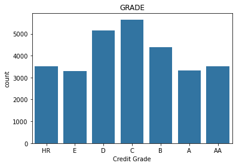

```python
sb.countplot(data=loan, x='CreditGrade' ,color = default_color);
plt.xlabel('Credit Grade');
plt.title('GRADE');
```

```python
loan['EmploymentStatus'].value_counts()
```

```
Employed         67322
Full-time        26355
Self-employed     6134
Not available     5347
Other             3806
Part-time         1088
Not employed       835
Retired            795
Name: EmploymentStatus, dtype: int64
```

```python
# Convert Employement Ststus to an ordered type

emp_order = ['Employed','Self-employed','Full-time','Part-time','Retired','Other','Not employed', 'Not available']
ordered_var = pd.api.types.CategoricalDtype(ordered = True, categories = emp_order)
loan.EmploymentStatus = loan.EmploymentStatus.astype(ordered_var, copy=True)
```

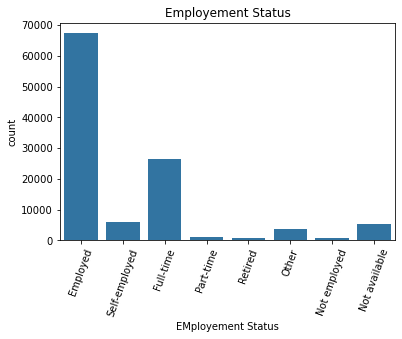

```python
sb.countplot(data=loan, x='EmploymentStatus' ,color = default_color);
plt.xlabel('EMployement Status');
plt.xticks(rotation=70)
plt.title('Employement Status');
```

```python
type_order = loan['Term'].value_counts().index
type_order
```

```
Int64Index([36, 60, 12], dtype='int64')
```

Majority of the borrowers are employed

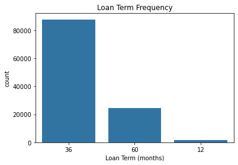

```python
type_order = loan['Term'].value_counts().index
sb.countplot(data=loan, x='Term', color=default_color,order=type_order);
plt.xlabel('Loan Term (months)');
plt.title('Loan Term Frequency');
```

loan term length of majority borrowers is 36 month

```python
loan['BorrowerAPR'].describe()
```

```
count    113912.000000
mean          0.218828
std           0.080364
min           0.006530
25%           0.156290
50%           0.209760
75%           0.283810
max           0.512290
Name: BorrowerAPR, dtype: float64
```

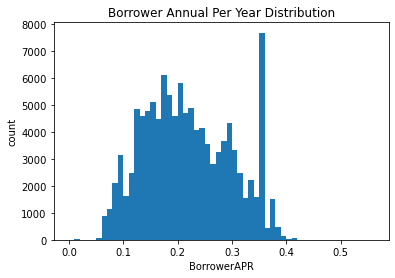

```python
# borrower APR distribution


bins = np.arange(0,loan['BorrowerAPR'].max()+0.05,0.01)
plt.hist(data=loan,x='BorrowerAPR',bins=bins)
plt.xlabel('BorrowerAPR')
plt.ylabel('count')
plt.title('Borrower Annual Per Year Distribution');
```

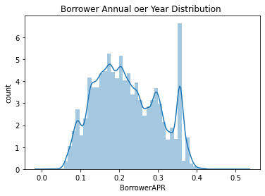

```python
# borrower APR distribution using seaborn
sb.distplot(loan['BorrowerAPR'])
plt.ylabel('count')
plt.title('Borrower Annual oer Year Distribution ');
```

THis shows that there is a high peak between 0.35 to 0.38 and low borrower APR below 0.4

```python
loan['BorrowerRate'].describe()
```

```
count    113937.000000
mean          0.192764
std           0.074818
min           0.000000
25%           0.134000
50%           0.184000
75%           0.250000
max           0.497500
Name: BorrowerRate, dtype: float64
```

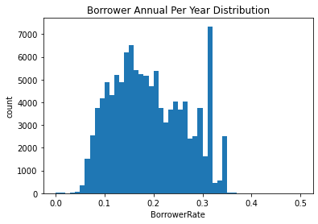

```python
# borrowerrate distribution
bins = np.arange(0,loan['BorrowerRate'].max()+0.01,0.01)
plt.hist(data=loan,x='BorrowerRate',bins=bins)
plt.xlabel('BorrowerRate')

plt.ylabel('count')
plt.title('Borrower Annual Per Year Distribution');
```

It is right skewed distribution. After 0.1 rate their is decrease in count but increase around 0.3 and their is sudden increase in the count 0.33

```python
loan['ListingCreationDate']
```

```
0        2007-08-26 19:09:29.263
1        2014-02-27 08:28:07.900
2        2007-01-05 15:00:47.090
3        2012-10-22 11:02:35.010
4        2013-09-14 18:38:39.097
                   ...
113932   2013-04-14 05:55:02.663
113933   2011-11-03 20:42:55.333
113934   2013-12-13 05:49:12.703
113935   2011-11-14 13:18:26.597
113936   2014-01-15 09:27:37.657
Name: ListingCreationDate, Length: 113937, dtype: datetime64[ns]
```

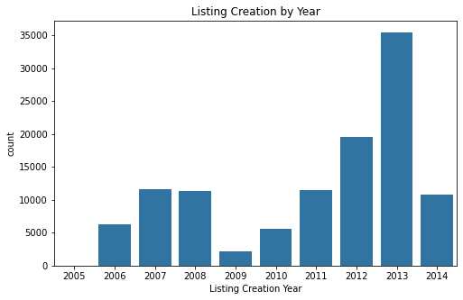

```python
# Listing Creation  by Year
plt.figure(figsize=[8, 5])
sb.countplot(data=loan,x=loan['ListingCreationDate'].dt.year,color=default_color)
plt.title('Listing Creation by Year')
plt.xlabel('Listing Creation Year');
```

there was a dropdown of listing cretaion in 2009 for reason unknow but recover in 2010 and 2013 has the higest number of listing created

```python
#borrower statw
loan['BorrowerState'].unique()
```

```
array(['CO', 'GA', 'MN', 'NM', 'KS', 'CA', 'IL', 'MD', nan, 'AL', 'AZ',
       'VA', 'FL', 'PA', 'OR', 'MI', 'NY', 'LA', 'WI', 'OH', 'NC', 'WA',
       'NV', 'NJ', 'TX', 'AR', 'SC', 'DE', 'MO', 'NE', 'UT', 'DC', 'MA',
       'CT', 'IN', 'KY', 'OK', 'MS', 'WV', 'RI', 'TN', 'ID', 'MT', 'HI',
       'NH', 'VT', 'WY', 'ME', 'AK', 'IA', 'SD', 'ND'], dtype=object)
```

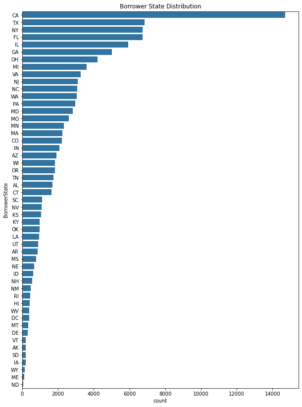

```python
#'Borrower State Distribution'
order=loan['BorrowerState'].value_counts().index
plt.figure(figsize=[10,14])
sb.countplot(data=loan,y='BorrowerState',color=default_color,order=order)
plt.title('Borrower State Distribution');
```

The distribution shows that the state CA has more borrowers followered by Tx

```python
loan['Occupation'].unique()
```

```
array(['Other', 'Professional', 'Skilled Labor', 'Executive',
       'Sales - Retail', 'Laborer', 'Food Service', 'Fireman',
       'Waiter/Waitress', 'Construction', 'Computer Programmer',
       'Sales - Commission', 'Retail Management', 'Engineer - Mechanical',
       'Military Enlisted', 'Clerical', nan, 'Teacher', 'Clergy',
       'Accountant/CPA', 'Attorney', 'Nurse (RN)', 'Analyst',
       "Nurse's Aide", 'Investor', 'Realtor', 'Flight Attendant',
       'Nurse (LPN)', 'Military Officer', 'Food Service Management',
       'Truck Driver', 'Administrative Assistant',
       'Police Officer/Correction Officer', 'Social Worker',
       'Tradesman - Mechanic', 'Medical Technician', 'Professor',
       'Postal Service', 'Civil Service', 'Pharmacist',
       'Tradesman - Electrician', 'Scientist', 'Dentist',
       'Engineer - Electrical', 'Architect', 'Landscaping',
       'Tradesman - Carpenter', 'Bus Driver', 'Tradesman - Plumber',
       'Engineer - Chemical', 'Doctor', 'Chemist',
       'Student - College Senior', 'Principal', "Teacher's Aide",
       'Pilot - Private/Commercial', 'Religious', 'Homemaker',
       'Student - College Graduate Student', 'Student - Technical School',
       'Psychologist', 'Biologist', 'Student - College Sophomore',
       'Judge', 'Student - College Junior', 'Car Dealer',
       'Student - Community College', 'Student - College Freshman'],
      dtype=object)
```

```python
#checking the value counts of all the occupation
with pd.option_context('display.max_rows', None, 'display.max_columns', None):
    print(loan['Occupation'].value_counts())
```

```
Other                                 28617
Professional                          13628
Computer Programmer                    4478
Executive                              4311
Teacher                                3759
Administrative Assistant               3688
Analyst                                3602
Sales - Commission                     3446
Accountant/CPA                         3233
Clerical                               3164
Sales - Retail                         2797
Skilled Labor                          2746
Retail Management                      2602
Nurse (RN)                             2489
Construction                           1790
Truck Driver                           1675
Laborer                                1595
Police Officer/Correction Officer      1578
Civil Service                          1457
Engineer - Mechanical                  1406
Military Enlisted                      1272
Food Service Management                1239
Engineer - Electrical                  1125
Food Service                           1123
Medical Technician                     1117
Attorney                               1046
Tradesman - Mechanic                    951
Social Worker                           741
Postal Service                          627
Professor                               557
Realtor                                 543
Doctor                                  494
Nurse (LPN)                             492
Nurse's Aide                            491
Tradesman - Electrician                 477
Waiter/Waitress                         436
Fireman                                 422
Scientist                               372
Military Officer                        346
Bus Driver                              316
```

[output cut: 13 more lines]

```
Psychologist                            145
Biologist                               125
Religious                               124
Flight Attendant                        123
Tradesman - Carpenter                   120
Homemaker                               120
Student - College Junior                112
Tradesman - Plumber                     102
Student - College Sophomore              69
Dentist                                  68
Student - College Freshman               41
Student - Community College              28
Judge                                    22
Student - Technical School               16
Name: Occupation, dtype: int64
```

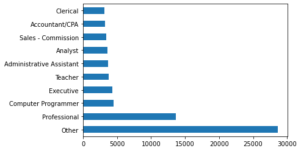

```python
# occupation greater than 3000
occupation=loan['Occupation'].value_counts()
occupation[occupation > 3000].plot.barh();
```

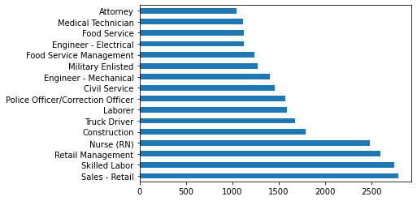

```python
# occupation greater than 3000
occupation[(occupation > 1000) & (occupation < 3000)].plot.barh();
```

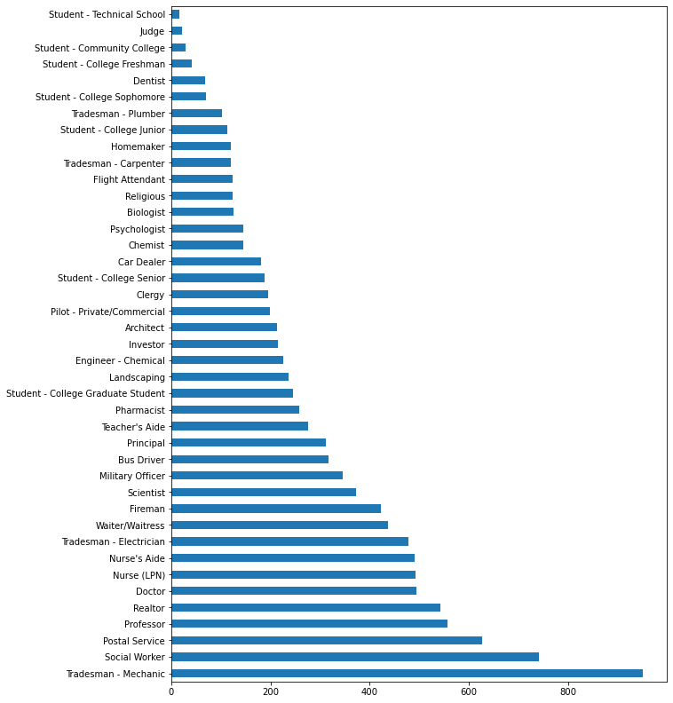

```python
# occupation greater than 3000
plt.figure(figsize=[10,14])
occupation[(occupation > 10) & (occupation < 1000)].plot.barh();
```

The three major occupation that borrows money respectively are other, professional and computer programmers while the least occupation that borrowes money respectively are student- Tecnical school,judge and student-community college

```python
loan['LoanOriginalAmount'].describe()
```

```
count    113937.00000
mean       8337.01385
std        6245.80058
min        1000.00000
25%        4000.00000
50%        6500.00000
75%       12000.00000
max       35000.00000
Name: LoanOriginalAmount, dtype: float64
```

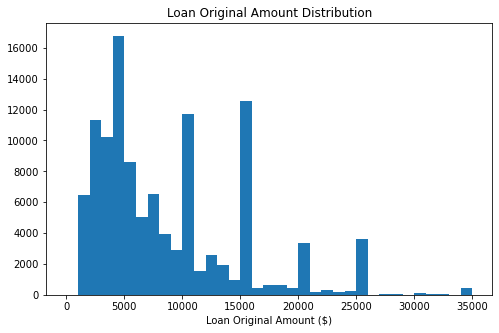

```python
# Loan Original Amount Distribution
binsize = 1000
bins = np.arange(0, loan['LoanOriginalAmount'].max()+binsize, binsize)

plt.figure(figsize=[8, 5])
plt.hist(data =loan, x = 'LoanOriginalAmount', bins = bins)
plt.xlabel('Loan Original Amount ($)')
plt.title('Loan Original Amount Distribution');
```

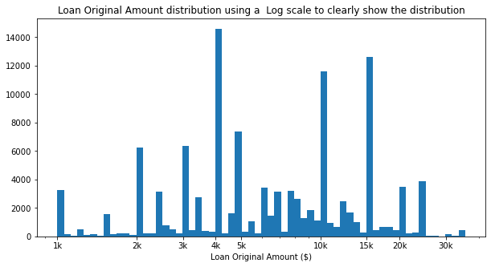

```python
# Putting it in a log-scale
log_binsize = 0.025
bins = 10 ** np.arange(3, np.log10(loan['LoanOriginalAmount'].max())+log_binsize, log_binsize)

plt.figure(figsize=[10, 5])
plt.hist(data = loan, x = 'LoanOriginalAmount', bins = bins)
plt.xscale('log')
plt.xticks([1000, 2000, 3000, 4000, 5000, 10000, 15000,20000, 30000], ['1k','2k', '3k', '4k', '5k', '10k','15k', '20k','30k'])
plt.xlabel('Loan Original Amount ($)')
plt.title('Loan Original Amount distribution using a  Log scale to clearly show the distribution');
```

From the graph shows that 4k ,10k and 15k has a higher peak , which goes to say that 4k,10k and 15k and the most amount people borrow

```python
loan['DebtToIncomeRatio'].describe()
```

```
count    105383.000000
mean          0.275947
std           0.551759
min           0.000000
25%           0.140000
50%           0.220000
75%           0.320000
max          10.010000
Name: DebtToIncomeRatio, dtype: float64
```

```
''
```

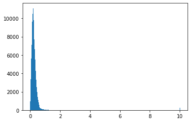

```python
# debt to income ration
bins=np.arange(0,loan['DebtToIncomeRatio'].max()+0.03,0.03)
plt.hist(data=loan,x='DebtToIncomeRatio',bins=bins)
;
```

the destribution is skew to the right and all falls under 0 to 1 which might deduce an outliers .hence lets use log scale to show the graph

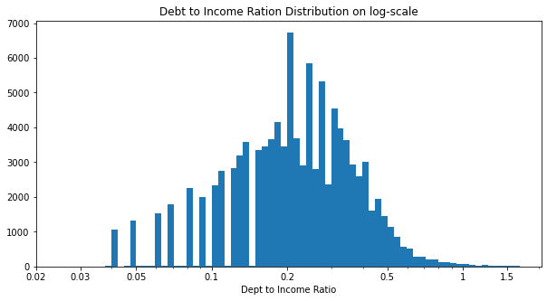

```python
#Debt to Income Ration Distribution with log scale
bins = 10 ** np.arange(-1.5, 0.25, log_binsize)
plt.figure(figsize=[10, 5])
plt.hist(data = loan, x = 'DebtToIncomeRatio', bins = bins)
plt.xscale('log')
plt.xticks([2e-2, 3e-2, 5e-2, 1e-1, 2e-1, 5e-1, 1, 1.5], ['0.02','0.03', '0.05', '0.1', '0.2', '0.5', '1', '1.5'])
plt.xlabel('Dept to Income Ratio')
plt.title('Debt to Income Ration Distribution on log-scale');
```

using log scales this shows that the Dept to income ration are desttributed normally from 0.2

```python
loan['StatedMonthlyIncome'].describe()
```

```
count    1.139370e+05
mean     5.608026e+03
std      7.478497e+03
min      0.000000e+00
25%      3.200333e+03
50%      4.666667e+03
75%      6.825000e+03
max      1.750003e+06
Name: StatedMonthlyIncome, dtype: float64
```

```
''
```

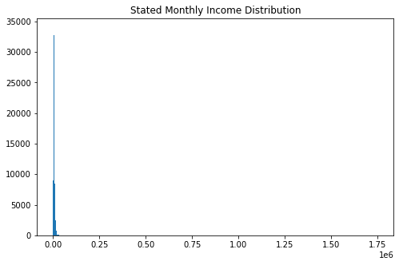

```python
# Stated Monthly income distribution
bins = np.arange(0, loan['StatedMonthlyIncome'].max()+2000, 2000)

plt.figure(figsize=[8, 5])
plt.hist(data = loan, x = 'StatedMonthlyIncome', bins = bins)
plt.title('Stated Monthly Income Distribution')
;
```

the destribution is skew to the right and all falls under 0.00 which might deduce an outliers .hence lets use log scale to show the graph

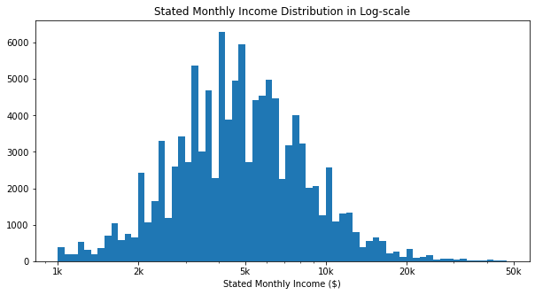

```python
# Using log-scale

log_binsize = 0.025
bins = 10 ** np.arange(3, 4.7, log_binsize)

plt.figure(figsize=[10, 5])
plt.hist(data = loan ,x = 'StatedMonthlyIncome', bins = bins)
plt.xscale('log')
plt.xticks([1e3, 2e3, 5e3, 1e4, 2e4, 5e4], ['1k', '2k','5k', '10k', '20k', '50k'])
plt.xlabel('Stated Monthly Income ($)')
plt.title('Stated Monthly Income Distribution in Log-scale')
plt.show()
```

it has a normal destribution with a peak of around 5k

```python
loan['MonthlyLoanPayment'].describe()
```

```
count    113937.000000
mean        272.475783
std         192.697812
min           0.000000
25%         131.620000
50%         217.740000
75%         371.580000
max        2251.510000
Name: MonthlyLoanPayment, dtype: float64
```

```
''
```

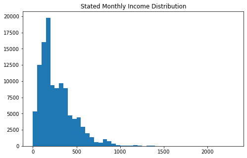

```python
# Stated Monthly loan distribution
bins = np.arange(0, loan['MonthlyLoanPayment'].max()+50, 50)

plt.figure(figsize=[8, 5])
plt.hist(data = loan, x = 'MonthlyLoanPayment', bins = bins)
plt.title('Stated Monthly Income Distribution')
;
```

using log scale to show in detail about the destribution

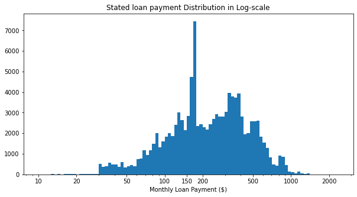

```python
log_binsize = 0.025
bins = 10 ** np.arange(1, np.log10(loan['MonthlyLoanPayment'].max())+log_binsize, log_binsize)

plt.figure(figsize=[10, 5])
plt.hist(data = loan, x = 'MonthlyLoanPayment', bins = bins)
plt.xscale('log')
plt.xticks([10, 20, 50, 100 ,150,200, 500, 1e3, 2e3], ['10', '20','50', '100','150','200', '500', '1000', '2000'])
plt.xlabel('Monthly Loan Payment ($)')
plt.title('Stated loan payment Distribution in Log-scale')
plt.show()
```

from the destribution,it shows that that 170 dollars is the peak and the most montly loan payment is 170 dollars

### Discuss the distribution(s) of your variable(s) of interest. Were there any unusual points? Did you need to perform any transformations?

### Of the features you investigated, were there any unusual distributions? Did you perform any operations on the data to tidy, adjust, or change the form of the data? If so, why did you do this?

> When the long-tailed, skewed distributions of specific varibles such as 'MonthlyLoanPayment','StatedMonthlyIncome','DebtToIncomeRatio','LoanOriginalAmount' were verified on a log-scale, the distribution was more visible and uderstadable.

## Bivariate Exploration

> We need to recognize numerical and categorical properties in order to choose the appropriate chart type to explore variables in pairs.

```python
#Create lists for numeric and categorical variables
numerical_vars =['BorrowerAPR', 'DebtToIncomeRatio','BorrowerRate',\
               'StatedMonthlyIncome', 'LoanOriginalAmount', 'MonthlyLoanPayment']
categorical_vars = ['LoanStatus', 'BorrowerState', 'Occupation', 'EmploymentStatus',\
                    'CreditGrade','Team']
```

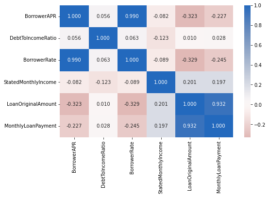

```python
# correlation plot
plt.figure(figsize = [8, 5])
sb.heatmap(loan[numerical_vars].corr(), annot = True, fmt = '.3f',
           cmap = 'vlag_r', center = 0)
plt.show()
```

```
loan.shape= (113937, 14)
loan_samp.shape= (500, 14)
```

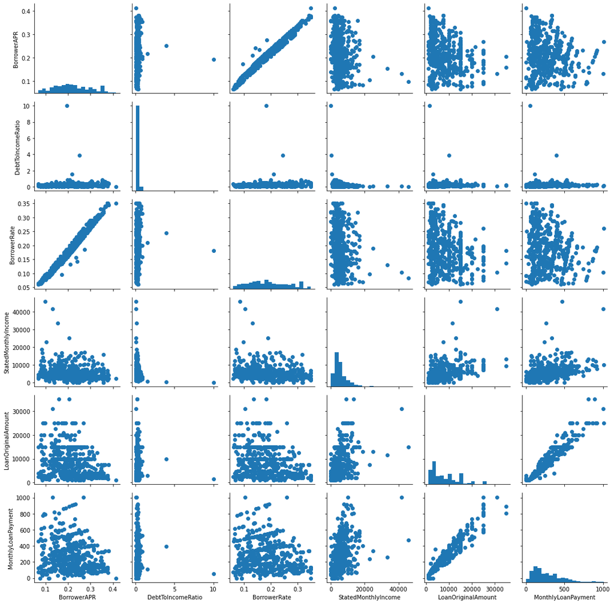

```python
# plot matrix:
print("loan.shape=",loan.shape)
loan_samp = loan.sample(n=500, replace = False)
print("loan_samp.shape=",loan_samp.shape)

g = sb.PairGrid(data = loan_samp, vars = numerical_vars)
g = g.map_diag(plt.hist, bins = 20);
g.map_offdiag(plt.scatter)
```

- The scatter plot demonstrates that these borrower rate and loan original amount are negatively correlated,supporting the idea that the lower the APR, the greater the loan amount.
- The loan original amount is positively correlated with the stated monthly income with correlation coefficient, it shows that since borrowers with more monthly income could loan more money.

Let's move on to looking at how borrower APR, stated monthly income and loan original amount correlate with the categorical variables.

```python
numerical_v=['BorrowerAPR','LoanOriginalAmount']
```

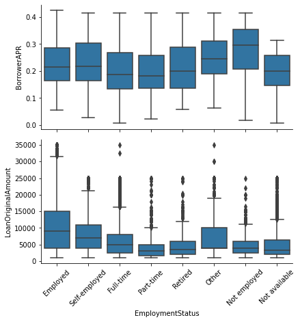

```python
def box_grid(x,y,**kwargs):
    """ Quick hack for creating box plots with seaborn's PairGrid. """
    default_color = sb.color_palette()[0]
    sb.boxplot(x,y,color=default_color)
# apply box_grid function on Employment status variable
g = sb.PairGrid(data=loan ,y_vars=numerical_v,x_vars='EmploymentStatus',height=3,aspect=2)
g.map(box_grid)

for ax in g.axes.flatten():
    # rotate x axis labels
    plt.setp(ax.get_xticklabels(), rotation=45);
```

it is noticed from the box plot that Employed people can get larger loan amounts compared to all other categories

```python
# Convert loan status to an ordered type

rate_order = ['Completed','Current','Chargedoff','Defaulted','Past Due (1-15 days)',\
              'Past Due (16-30 days)','Past Due (31-60 days)','Past Due (61-90 days)',\
              'Past Due (91-120 days)','Past Due (>120 days)','FinalPaymentInProgress','Cancelled']
ordered_var = pd.api.types.CategoricalDtype(ordered = True, categories = rate_order)
loan.LoanStatus = loan.LoanStatus.astype(ordered_var, copy=True)
```

```python
loan.LoanStatus.value_counts()
```

```
Current                   56576
Completed                 38074
Chargedoff                11992
Defaulted                  5018
Past Due (1-15 days)        806
Past Due (31-60 days)       363
Past Due (61-90 days)       313
Past Due (91-120 days)      304
Past Due (16-30 days)       265
FinalPaymentInProgress      205
Past Due (>120 days)         16
Cancelled                     5
Name: LoanStatus, dtype: int64
```

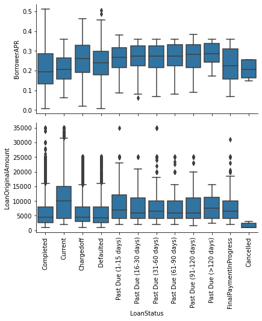

```python
def box_grid(x,y,**kwargs):
    """ Quick hack for creating box plots with seaborn's PairGrid. """
    default_color = sb.color_palette()[0]
    sb.boxplot(x,y,color=default_color)
# apply box_grid function on Employment status variable
g = sb.PairGrid(data=loan ,y_vars=numerical_v,x_vars='LoanStatus',height=3,aspect=2)
g.map(box_grid)

for ax in g.axes.flatten():
    # rotate x axis labels
    plt.setp(ax.get_xticklabels(), rotation=90);
```

Current and completed loans have lower rate than the past-due loans

Finally, let's look at relationships between the categorical features.

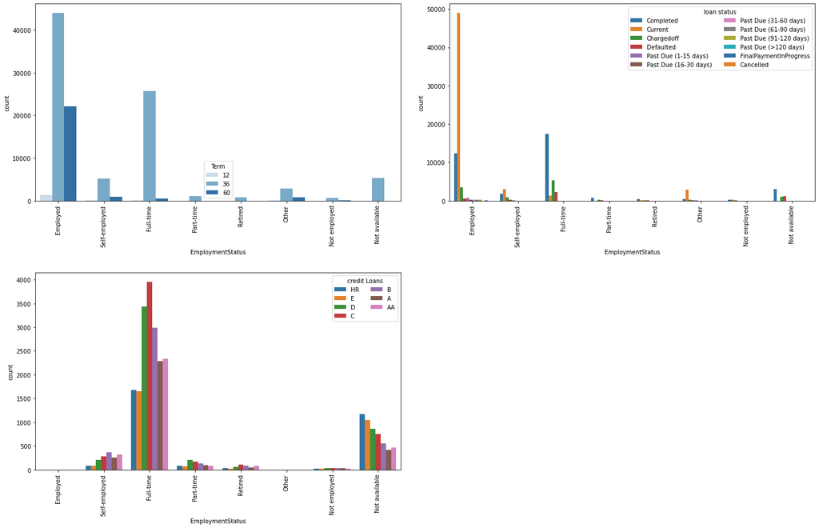

```python
fig= plt.figure(figsize=[20,50])
ax1=plt.subplot(8,2,1)
sb.countplot(data = loan, x = 'EmploymentStatus', hue = 'Term', palette = 'Blues')
plt.xticks(rotation=90)

ax2=plt.subplot(8,2,2)
sb.countplot(data = loan, x = 'EmploymentStatus', hue = 'LoanStatus',palette='tab10')
plt.xticks(rotation=90)
ax2.legend(loc = 1, ncol = 2,title='loan status')

ax3=plt.subplot(8,2,3)
sb.countplot(data = loan, x = 'EmploymentStatus', hue = 'CreditGrade',palette='tab10')
plt.xticks(rotation=90)
ax3.legend(loc = 1, ncol = 2,title='credit Loans')


fig.tight_layout(pad=3.0);
```

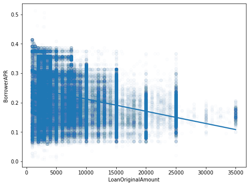

```python
 #scatter plot of price vs. carat, with log transform on price axis

plt.figure(figsize = [8, 6])
sb.regplot(data=loan,x='LoanOriginalAmount',y='BorrowerAPR',scatter_kws={'alpha':0.01})
```

This shows that the borrower APR is negatively correlated with loan amount.

### Talk about some of the relationships you observed in this part of the investigation. How did the feature(s) of interest vary with other features in the dataset?

> i observed that the broweer APR is negativatly corrolated to the original amount,which goes to say the more the original amount the lesser the APR

### Multivariate Exploration

The main thing I want to explore in this part of the analysis is how the categorical variable ( LoanStatus,term & creditgrade) play into the relationship between borrower APR and loan original amount.

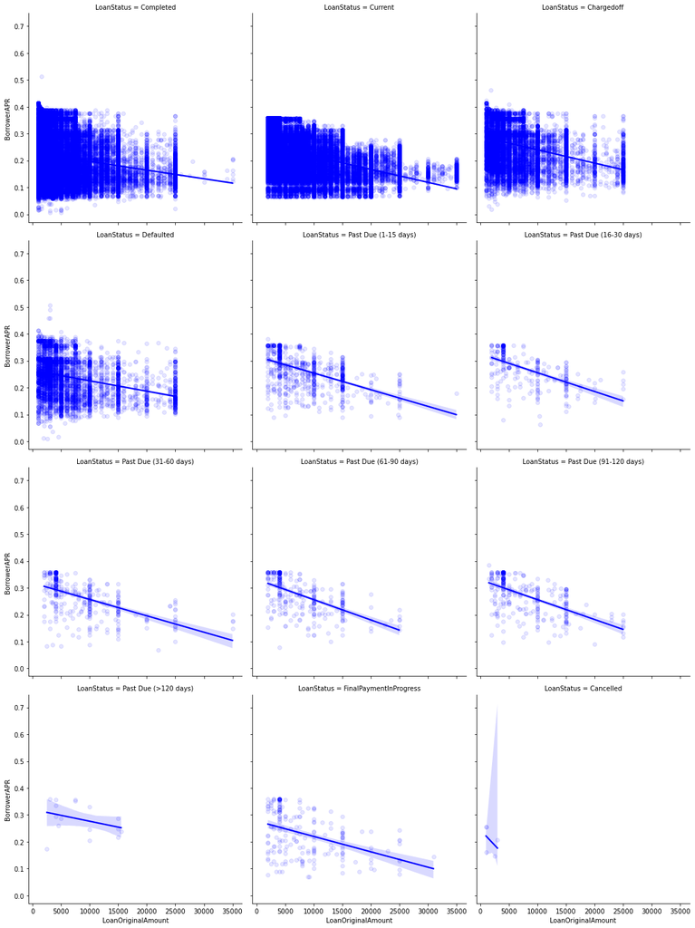

```python
# a graph of loan status over loan original amont and borrower APR
g = sb.FacetGrid(data = loan, col = 'LoanStatus', col_wrap = 3, height = 5)

g.map(sb.regplot, 'LoanOriginalAmount', 'BorrowerAPR', color = 'Blue', x_jitter=0.04, scatter_kws={'alpha':0.1})
g.set_xlabels('LoanOriginalAmount')
g.set_ylabels('BorrowerAPR')

plt.show()
```

loan status has negative effect on loan original amont and borrower APR

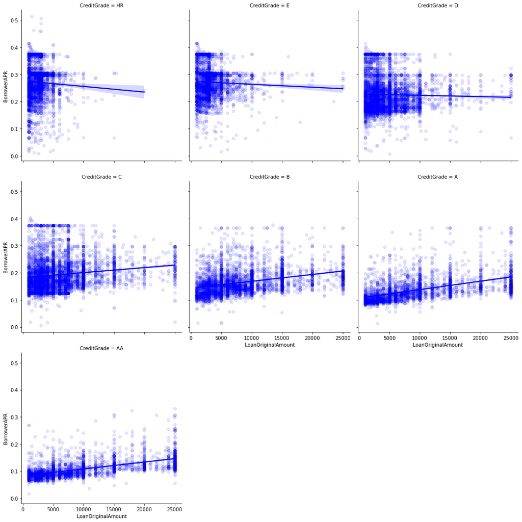

```python
# a graph of loan status over loan original amont and borrower APR
g = sb.FacetGrid(data = loan, col = 'CreditGrade', col_wrap = 3, height = 5)

g.map(sb.regplot, 'LoanOriginalAmount', 'BorrowerAPR', color = 'Blue',x_jitter=0.04, scatter_kws={'alpha':0.1})
g.set_xlabels('LoanOriginalAmount')
g.set_ylabels('BorrowerAPR')

plt.show()
```

The loan amount increases with better creditscore. The borrower APR decreases with better score. Interestingly, the relationship between borrower APR and loan amount turns from negative to slightly positive

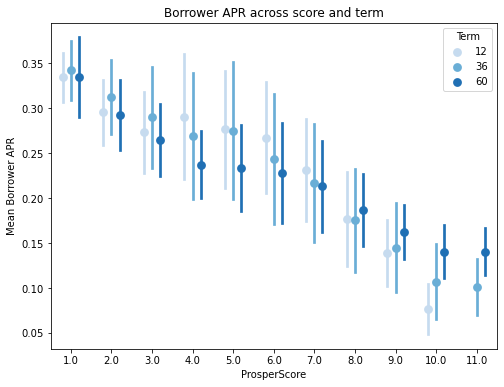

```python
# look at the score and term effects on BorrowerAPR
plt.figure(figsize=[8,6])
ax = sb.pointplot(data=loan,x='ProsperScore',y='BorrowerAPR',hue='Term',palette='Blues',linestyles='',dodge=0.4,ci='sd')
plt.title("Borrower APR across score and term")
plt.ylabel('Mean Borrower APR')
ax.set_yticklabels([],minor = True);
```

```
''
```

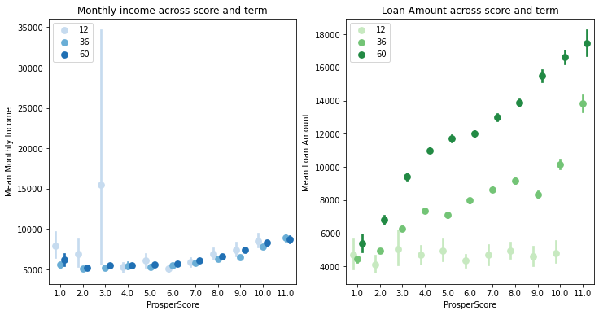

```python
# look at the score and term effects on stated monthly income and loan original amount variables
fig, ax = plt.subplots(ncols=2, figsize=[12,6])
sb.pointplot(data = loan, x = 'ProsperScore', y = 'StatedMonthlyIncome', hue = 'Term',
           palette = 'Blues', linestyles = '', dodge = 0.4, ax=ax[0])

ax[0].set_title("Monthly income across score and term")
ax[0].set_ylabel("Mean Monthly Income")
ax[0].legend(loc='upper left')

sb.pointplot(data = loan, x = 'ProsperScore', y = 'LoanOriginalAmount', hue = 'Term',
           palette = 'Greens', linestyles = '', dodge = 0.4, ax=ax[1])
ax[1].set_title("Loan Amount across score and term")
ax[1].set_ylabel("Mean Loan Amount")
ax[1].legend(loc='upper left')
;
```

### Talk about some of the relationships you observed in this part of the investigation. Were there features that strengthened each other in terms of looking at your feature(s) of interest?

> The borrower's APR and loan amount is negative correction when the are from HR to D, but the correlation is turned to be positive when the ratings are Cand AA.

### Were there any interesting or surprising interactions between features?

> A surprising interaction is that the borrower APR and loan amount is negatively correlated to loanstatus